# Prediction as proof of learning

Given a set of instances, a learner seeks to anticipate unseen events. We will consider the cases of predicting

- a (set of) continuous variables (**regression**)
- a (set of) discrete variables (**classification**) and

given some unseen instances.

```python
%matplotlib inline
import os
import numpy as np
import scipy as sp
import pandas as pd
import matplotlib.pyplot as plt
from mpl_toolkits.mplot3d import axes3d
import seaborn as sns
from sklearn import datasets
from sklearn.neighbors.kde import KernelDensity
```

# Example: regression

- **Regression**: learning the intercept and slope of a straight line fit to a set of points

```python
def f(x):
    return 0.5*(x)*(x**4)/(.05+(x**4))
X=np.linspace(0,1,50)
y0=f(X)+0.03*np.random.normal(0,1,50)
```

```python
yhat1=np.polyfit(X,y0,deg=1)
yhat2=np.polyfit(X,y0,deg=2)
print("degree 1: ",yhat1)
print("degree 2: ",yhat2)
```

```
degree 1:  [ 0.54556636 -0.09305423]
degree 2:  [ 0.34931373  0.19625263 -0.03602342]
```

Notice that we have obtained two parameters -- the slope of the line and the y-intercept -- from 50 data points. There is only one unique straight line that can be drawn through 2 points. Are all the 50 points colinear? What is going on?

We next draw the points and the straight line graph to demonstrate the extent of the match between inferred line and the given data points.

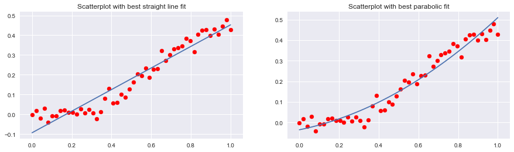

```python
fig, axes = plt.subplots(figsize=(15,4),nrows=1, ncols=2,sharex='col')
axes[0].plot(X,yhat1[0]*X+yhat1[1])
axes[0].scatter(X,y0,c='r')
axes[0].set_title('Scatterplot with best straight line fit')
axes[1].plot(X,yhat2[0]*X**2+yhat2[1]*X+yhat2[2])
axes[1].scatter(X,y0,c='r')
axes[1].set_title('Scatterplot with best parabolic fit')
```

What this allows us to **predict** are the values of $y$ corresponding to any choice of $x$ that might be provided as input.

To improve on what we have learnt we need to understand where we have gone wrong. Hence, we look at the *residuals* $r_i = \hat{y}(x_i) - y_i$. The target objective is to bring the residuals as close to 0 as possible. We shall see later that this may lead to **overfitting** and other constraints are often imposed to relax this drive towards reducing the residuals.

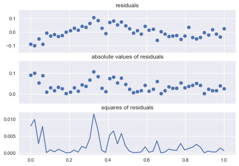

```python
fig, axes = plt.subplots(nrows=3, ncols=1,sharex='col')
axes[0].scatter(X,yhat1[1]+yhat1[0]*X-y0)
axes[0].set_title('residuals')
axes[1].scatter(X,np.abs(yhat1[1]+yhat1[0]*X-y0))
axes[1].set_title('absolute values of residuals')
axes[2].plot(X,np.square(yhat1[1]+yhat1[0]*X-y0))
axes[2].set_title('squares of residuals')
```

There is a package for drawing graphs called $\texttt{seaborn}$ from which we use the following function that calls ${\tt polyfit}$ when we invoke ${\tt fit}$_${\tt reg}.$  
We use this to illustrate how multiple models (here different choices of functions -- linear or quadratic) may be fit to the same data. The nature of the residuals determine which of the models best fits the data. Often more complex models with many parameters do a better job of fitting the training data but fare more poorly on unseen data.

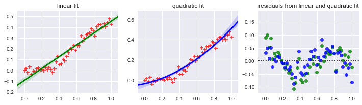

```python
fig, axes = plt.subplots(nrows=1, ncols=3)
sns.regplot(X,y0,fit_reg=True,ax=axes[0],order=1,marker='+',scatter_kws={'color':'r'},line_kws={'color':'g'})
sns.regplot(X,y0,fit_reg=True,ax=axes[1],order=2,marker='+',scatter_kws={'color':'r'},line_kws={'color':'b'})
sns.residplot(X,y0,ax=axes[2],order=1,scatter_kws={'color':'g'})
sns.residplot(X,y0,ax=axes[2],order=2,scatter_kws={'color':'b'})
axes[0].set_title('linear fit')
axes[1].set_title('quadratic fit')
axes[2].set_title('residuals from linear and quadratic fit')
fig.set_size_inches((12,3))
```

Notice that there is a green straight line and a blue curved line. These are polynomials of order 1 -- $y(x)=ax+b$ -- and order 2 -- $y(x)=ax^2+bx+c$ -- that are fit to the data points in red.

The **residuals** $r_i = \hat{y}(x_i) - y_i$ are shown, appropriately colour coded. As expected they cluster around $0$. Some of the data points will lie above (below) the best-fit line and thus give a positive (negative) residual.

- We shall see how the same mathematical method from linear algebra is called to work for linear combinations of functions $\hat{y}(x)=w_1 f_1(x) + w_2 f_2(x) + \cdots + w_p f_p(x)$. The goal in that case would be to make the best estimates for $w_1, \ldots w_p$ given the data $(y_i, x_i)$ and a choice of functions $f_i$ so we can "*learn*" the regressor $\hat{y}$.
- The functions $f_i$ are often called "**features**" and the $w_i$ the "**weights**" with $p$ being the dimension of the feature space.

# Ordinary least squares

We will work through the basic algebra behind least-squares fitting next. The idea is to look at the residuals $r_i$ as components of a vector, and the weights $w_i$, also viewed as components of a vector. The weight vector $\mathbf{w}=(w_1,\ldots,w_p)$ is varied during the learning process in order to minimise the magnitude (**norm**) $\|\mathbf{r}\|$ of the vector $\mathbf{r}=(r_1, \ldots, r_N)$. $N$ denotes the number of training points $\{(x_1, y_1), \ldots, (x_N, y_N)\}$ while the dimension of the weight vector (**feature space**) is $p$. If the norm is taken to be: $$ \|\mathbf{r}\|_2 = \sqrt{r_1^2+\cdots+r_N^2}\quad \textbf{Euclidean norm} $$ the Euclidean norm (also called 2-norm or $L_2$-norm or $\ell_2$-norm), the objective of the training algorithm is to find $\mathbf{w}$ so that the sum of squares of the residuals is least, hence the name (ordinary) least squares minimisation. If residuals for different data points are assigned different weightings, the corresponding algorithm is called weighted least squares, and variants of this procedure have names like generalised least squares.

```
(x[0],y[0]): (0.000000, 2.868369)
(x[1],y[1]): (0.250000, 4.136457)
(x[2],y[2]): (0.500000, 3.696613)
(x[3],y[3]): (0.750000, 6.613044)
(x[4],y[4]): (1.000000, 9.291531)
```

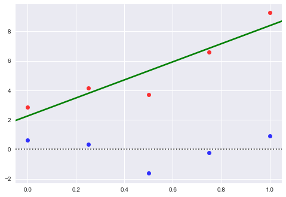

```python
from numpy.random import RandomState
perm_rand_gen = RandomState(2000)
npts=5
ranseq=perm_rand_gen.normal(0,1,npts)
X=np.linspace(0,1,npts)
y1=3*X**2+4*X+2+0.5*ranseq
for i in range(npts):
    print('(x[{}],y[{}]): ({:f}, {:.6f})'.format(i,i,X[i],y1[i]))
sns.regplot(X,y1,fit_reg=True,order=1,scatter_kws={'color':'r'},line_kws={'color':'g'},ci=None)
sns.residplot(X,y1,order=1,scatter_kws={'color':'b'})
```

The green line is a straight line plot $\hat{y}(x)=w_1 x+w_0$ where $w_1$ and $w_0$ have been estimated from the data given (note the hat on $\hat{y}$ -- it signals an estimated value, not a "true" data point). We'll describe the estimation of $w_0$ and $w_1$ is done next. The blue points are the $\textit{residuals}$ $r_i = \hat{y}(x_i) - y_i$. For each data point $(x_i, y_i)$, $$y_i = w_0 + w_1 x_i = w_0\times 1 + w_1\times x_i = \left(\begin{array}{cc}w_0& w_1\end{array}\right)\left(\begin{array}{c}1\\ x_i\end{array}\right).$$ This leads to the set of simulataneous linear equations $\mathbf{A}\mathbf{w}=\mathbf{y}$: $$ \left( \begin{array}{cc} 1&x_1\\1&x_2\\1&x_3\\1&x_4\\1&x_5 \end{array}\right)\left( \begin{array}{c} w_0\\w_1 \end{array}\right)=\left(\begin{array}{c} y_1\\y_2\\y_3\\y_4\\y_5 \end{array}\right), \mbox{ with } \mathbf{A}=\left( \begin{array}{cc} 1&x_1\\1&x_2\\1&x_3\\1&x_4\\1&x_5 \end{array}\right), $$ that we need to solve for $\mathbf{w}=(w_0,w_1)^T$. Since there are more equations than unknowns the system is called *overdetermined* and there is (in general) no solution. (The generic layout of any three points is non-colinear, as they can be identified with the vertices of a triangle. There could be 10 pairs chosen from the 5 points in the dataset and thus 10 distinct straight lines drawn through the data.)

The (5-by-2) matrix $\mathbf{A}$ is fixed, and by changing weight vectors $\mathbf{w}$ we obtain all possible 5-dimensional vectors that $\mathbf{A}$ is capable of generating. This is called the **column space** of the matrix $\mathbf{A}$. The target vector $\mathbf{y}$ is sought in this column space. The weight vector $\widehat{\mathbf{w}}$ for which the residual vector $\mathbf{r}=\mathbf{y}-\mathbf{A}\widehat{\mathbf{w}}$ is closest to 0 is the outcome of the learning algorithm.

Let us see what ${\tt numpy.polyfit}$ gives us.

```python
sol=np.polyfit(X,y1,deg=1)
wsol=np.asarray((sol[1],sol[0]))
Amat=np.transpose(np.concatenate(([np.ones(5)],[X]),axis=0))
r1=np.dot(Amat,wsol)-y1
min_rss=np.dot(r1,r1)
print('Result of learning: y-intercept w[0]=',wsol[0],'slope w[1]=',wsol[1])
print("residual vector: ",r1,"\nmin RSS: ",min_rss)
print("Dot product of design matrix Amat with residual vector: ",np.dot(np.transpose(Amat),r1))
```

```
Result of learning: y-intercept w[0]= 2.25662056751 slope w[1]= 6.12916437702
residual vector:  [-0.61174824 -0.34754529  1.62458947  0.2404499  -0.90574583]
min RSS:  4.01250623212
Dot product of design matrix Amat with residual vector:  [ -1.46549439e-14  -8.43769499e-15]
```

## Why did we take the dot product of the residual vector with the input data vector?

The weight vectors are the lens through which the light from the data is directed on the target. Different assignments of the weights $\mathbf{w}$ result in a different vector in the column space of the data matrix $\mathbf{A}$ constructed out of the input data points $\mathbf{x}$. The column space saturates the space of possibilities that the $\mathbf{Aw}$ can be. The optimal choice of $\widehat{\mathbf{w}}$ is one where the residual vector $\mathbf{r}=\mathbf{y}-\mathbf{A}\widehat{\mathbf{w}}$ is **zero in the subspace spanned by** $\mathbf{A}$ which is the column space. In other words, $$0=\mathbf{A}^T\mathbf{r}=\mathbf{A}^T(\mathbf{y}-\mathbf{A}\widehat{\mathbf{w}}).$$
Explicitly (and in our example, $N=5$), $$ \left(\begin{array}{c} r_1\\r_2\\\vdots\\\vdots\\r_N \end{array}\right)= \left(\begin{array}{c} y_1\\y_2\\\vdots\\\vdots\\y_N \end{array}\right)- \left( \begin{array}{cc} 1&x_1\\1&x_2\\\vdots&\vdots\\\vdots&\vdots\\1&x_N \end{array}\right)\left( \begin{array}{c} w_0\\w_1 \end{array}\right)=\left(\begin{array}{c} y_1-(w_0+x_1 w_1)\\y_2-(w_0+x_2 w_1)\\\vdots\\\vdots\\y_N-(w_0+x_N w_1 ) \end{array}\right). $$ For the *best fit* residual $$\mathbf{A}^T\mathbf{r}=\left(\begin{array}{c}r_1+r_2+\cdots+r_N\\x_1 r_1+x_1 r_2+\cdots+x_N r_N\end{array}\right)=\left(\begin{array}{c}0\\0\end{array}\right). $$

Notice that the sum of the residuals and therefore the average of the residuals is 0 -- the first entry in the 2-by-1 zero vector. This is roughly what you would expect -- some points are above the line, and some below the line, and there should not be any bias towards either. The second entry of the zero vector is the dot product of the input data with the residuals. This expresses the idea that once the data has been fit, there should not be any left over correlations between the errors and the inputs.

- This close relationship between the linear algebraic view (column space, projections, etc) of the learning problem and a statistical/probabilistic perspective (means, correlations) will show up repeatedly in machine learning.

```python
w0pts=np.linspace(-4,10,100)
w1pts=np.linspace(-8,10,100)
w0n, w1n = np.meshgrid(w0pts, w1pts, indexing='ij')
rss = np.zeros((w0pts.size,w0pts.size))

# Sum of squares of residuals (RSS) based on grid of (w0, w1) values
for (i,j),v in np.ndenumerate(rss):
    rss[i,j] =((y1 - (w0n[i,j]+X.ravel()*w1n[i,j]))**2).sum()
```

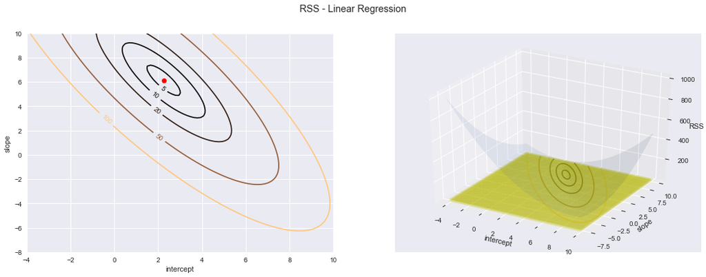

```python
fig = plt.figure(figsize=(18,6))
fig.suptitle('RSS - Linear Regression')

ax0 = fig.add_subplot(121)
ax1 = fig.add_subplot(122, projection='3d')

# Left plot
CS = ax0.contour(w0n, w1n, rss, cmap=plt.cm.copper, levels=[5, 10, 20, 50, 100])
ax0.scatter(sol[1], sol[0], c='r')
ax0.clabel(CS, inline=True, fontsize=10, fmt='%d')

# Right plot
ax1.plot_surface(w0n, w1n, rss,  alpha=0.1)
ax1.contour(w0n, w1n, rss, zdir='z', offset=rss.min(), cmap=plt.cm.copper,
            alpha=0.8, levels=[5, 10, 20, 50, 100])
ax1.scatter3D(w0n, w1n, min_rss, c='y',alpha=0.1)
ax1.set_zlabel('RSS')
ax1.set_zlim(rss.min(),rss.max())


# settings common to both plots
for ax in fig.axes:
    ax.set_xlabel('intercept')
    ax.set_ylabel('slope')
```

# Linear algebra: image and kernel of a matrix

Although we do not go into this now, we will revisit the example to draw out generic lessons about the circumstances under which the dot product of vectors is 0, the product of a matrix and a vector is 0 and so on. This suggests the existence of subspaces within vector spaces that vectors cannot be mapped into, and a partitioning of spaces associated with matrices. All in all, the issue of structures (patterns) within data that could be ripe for representing via matrix transformations and decompositions will be explored in greater depth.

- The matrix $\mathbf{A}$ can be written as a collection of $N$ row vectors or $p$ column vectors: $$\mathbf{A}=\left(\begin{array}{ccc} {\Big \uparrow}&&{\Big \uparrow}\\\mathbf{a}_1&\cdots&\mathbf{a}_N\\{\Big \downarrow}&&{\Big \downarrow} \end{array} \right)=\left(\begin{array}{ccc} { \longleftarrow}&\mathbf{a}_1&{\longrightarrow}\\&\vdots&\\{ \longleftarrow}&\mathbf{a}_p&{\longrightarrow} \end{array} \right).$$
- Consider the following 2 different perspectives on matrix-vector multiplication $\mathbf{Aw}$: $$\left(\begin{array}{cccc} a_{11}& a_{12} & \cdots& a_{1p}\\ a_{21}& a_{22} & \cdots& a_{2p}\\ \vdots & \vdots & \vdots& \vdots \\ a_{N1}&a_{N2}&\cdots&a_{Np} \end{array} \right)\left( \begin{array}{c} w_1\\w_2\\\vdots\\w_p \end{array}\right)=\underbrace{\left(\begin{array}{c}\sum_j a_{1j}w_j\\ \sum_j a_{2j}w_j\\\vdots\\\sum_j a_{Nj}w_j \end{array}\right)}_{\mbox{row view}}=\underbrace{\sum_j w_j\left( \begin{array}{c} a_{1j}\\a_{2j}\\\vdots\\a_{Nj} \end{array}\right)}_{\mbox{column view}}.$$
- Rewriting to illustrate the column view, we have
  $$\mathbf{Aw}=\left(\begin{array}{ccc} {\Big \uparrow}&&{\Big \uparrow}\\\mathbf{u}_1&\cdots&\mathbf{u}_p\\{\Big \downarrow}&&{\Big \downarrow} \end{array} \right)\left( \begin{array}{c} w_1\\w_2\\\vdots\\w_p \end{array}\right)=w_1\left( \begin{array}{c} {\Big \uparrow}\\\mathbf{u}_1\\{\Big \downarrow} \end{array}\right)+\cdots+w_p\left( \begin{array}{c} {\Big \uparrow}\\\mathbf{u}_p\\{\Big \downarrow} \end{array}\right),$$
- while the row view is rewritten thus: $$\mathbf{Aw}=\left(\begin{array}{ccc} { \longleftarrow}&\mathbf{v}_1&{\longrightarrow}\\&\vdots&\\{ \longleftarrow}&\mathbf{v}_N&{\longrightarrow} \end{array} \right)\left(\mathbf{w}\right)=\left( \begin{array}{c} \mathbf{v}_1\cdot \mathbf{w}\\\vdots\\\mathbf{v}_N\cdot \mathbf{w} \end{array}\right)$$
- The **column space** of a matrix ${A}$, denoted col(${A}$) is the subspace spanned by all linear combinations of the columns of $A$. This is also the range or image of the linear map:
  $$\mbox{col}(A)=\mbox{im}(A)=\mbox{range}(A)=A W = \{\mathbf{v}\in V:\mathbf{v} = A\mathbf{w} \mbox{ for some } \mathbf{w}\in W \}.$$ For any choice of real numbers $(w_1, \ldots, w_p)$, the range $V$ is the set of all vectors of the form $$\mathbf{v} = w_1\left( \begin{array}{c} {\Big \uparrow}\\\mathbf{u}_1\\{\Big \downarrow} \end{array}\right)+\cdots+w_p\left( \begin{array}{c} {\Big \uparrow}\\\mathbf{u}_p\\{\Big \downarrow} \end{array}\right).$$
- The weights $w_i$ quantify the contribution of feature *i* ($1\leq i \leq p$) that contributes to the match between model output $\mathbf{Aw}$ and target $\mathbf{y}$. The best fit weight vector $\hat{\mathbf{w}}$ is the one for which the residual $\mathbf{r}=\mathbf{y}-\mathbf{A}\hat{\mathbf{w}}$ is smallest.
- The residual cannot have any component in the column space of $\mathbf{A}$ or else a different $\mathbf{w}$ would have projected the data matrix $\mathbf{A}$ along that component. This is the meaning of the equation $$\mathbf{A}^T\mathbf{r}=\left(\begin{array}{c}0\\0\end{array}\right)$$ shown above. The residual is said to lie in the **nullspace** or **kernel** of the matrix $\mathbf{A}$, denoted ker($\mathbf{A}$).
- This leads to a formula for the best fit $\hat{\mathbf{w}}$: $$\mathbf{A}^T(\mathbf{y}-\mathbf{A}\hat{\mathbf{w}})=0 \implies \mathbf{A}^T\mathbf{A}\hat{\mathbf{w}} = \mathbf{A}^T\mathbf{y} \implies \hat{\mathbf{w}} = (\mathbf{A}^T\mathbf{A})^{-1} \mathbf{A}^T\mathbf{y}.$$
- The matrix $$(\mathbf{A}^T\mathbf{A})^{-1} \mathbf{A}^T$$ is called the **Moore-Penrose pseudo-inverse** of matrix $\mathbf{A}$.

Now that we have an explicit linear algebraic formula to plug the data into, let us return to the dataset of 5 points. First, print out the points again:

```python
print("(x,y) values:\n", np.stack((X,y1)).transpose())
Amat=np.stack((np.ones(5),X)).transpose()
print("Design matrix A:\n ",Amat)
print("Best fit w0 and w1 values:\n ",np.dot(np.linalg.pinv(Amat),y1))
sol=np.polyfit(X,y1,deg=1)
print("Calling polyfit gives:\n",sol)
```

```
(x,y) values:
 [[ 0.          2.86836881]
 [ 0.25        4.13645695]
 [ 0.5         3.69661329]
 [ 0.75        6.61304395]
 [ 1.          9.29153078]]
Design matrix A:
  [[ 1.    0.  ]
 [ 1.    0.25]
 [ 1.    0.5 ]
 [ 1.    0.75]
 [ 1.    1.  ]]
Best fit w0 and w1 values:
  [ 2.25662057  6.12916438]
Calling polyfit gives:
 [ 6.12916438  2.25662057]
```

# Example: classification

When the target variable is a discrete variable (we shall consider binary variables next) the task is one of classification. We introduce **logistic regression** as a method of preforming classification based on **log-odds** -- if $Pr$ is the probability of the occurrence of an event then $1-Pr$ is the probability of the event not occurring, with their ratio called the *odds* (a term used in betting, for instance). The log-odds is called the **logit** parameter $\lambda$: $$ \lambda = \log\left(\frac{Pr}{1-Pr}\right).$$

- Logistic regression treats the logit parameter as the target of linear regression: $$\lambda = w_0 + w_1 x.$$
- The inverse transformation $$Pr(x) = \frac{1}{1+e^{-w_0-w_1 x}}$$ goes by several names -- logistic regression curve, softmax function, sigmoid function, Fermi-Dirac statistical distribution, maximum entropy (MaxEnt) classifier.

If for two different inputs $x_1$ and $x_2$, we may use the logistic regression function to say

- $Pr(x_1) < 0.5$ ($\lambda <0$) therefore $x_1$ belongs to category 1
- $Pr(x_2) > 0.5$ ($\lambda >0$) therefore $x_2$ belongs to category 2

$\lambda=0$ is the **decision boundary**.

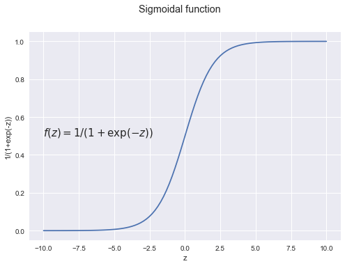

```python
xv=np.linspace(-10,10,100)
yv=1/(1+np.exp(-xv))
fig = plt.figure()
fig.suptitle('Sigmoidal function')
ax = fig.add_subplot(111)
ax.plot(xv,yv)
ax.set_xlabel('z')
ax.set_ylabel('1/(1+exp(-z))')
ax.text(-10.,0.5, r'$f(z)=1/(1+\exp(-z))$', fontsize=15)
```

```python
df = pd.read_csv('data/Default.csv')
```

A simulated data-set used in the textbook *An Introduction to Statistical Learning with applications in R* by James, G., Witten, D., Hastie, T., and Tibshirani, R. (2013). I have copied this file onto the course web-site at [https://secure.ecs.soton.ac.uk/notes/comp3206/Default.csv].

*Format*: A csv file with 10000 data vectors.

- *default* -- A binary variable indicating (No, Yes) whether customer has defaulted on debt
- *student* -- Is the customer a student? (No, Yes)
- *balance* -- The average balance on customer's credit card after monthly payment
- *income* -- Customer income

The data is loaded into a *DataFrame* class **df**, a default wrapper around a dictionary in python created in the package **pandas**. To see what the data looks like, let us print the first 5 entries using the function call **head()** inside the class **df**.

```python
print("Using pandas\n")
print("type of df is ",type(df))
print("the keys of the data dictionary:\n", df.keys())
print("first 5 entries:\n",df.head(5))
print("3rd row 5th col df[2,4]: ", df.values[2,4], " also ", df['income'][2]) # values() returns a numpy array
```

```
Using pandas

type of df is  <class 'pandas.core.frame.DataFrame'>
the keys of the data dictionary:
 Index(['Unnamed: 0', 'default', 'student', 'balance', 'income'], dtype='object')
first 5 entries:
    Unnamed: 0 default student      balance        income
0           1      No      No   729.526495  44361.625074
1           2      No     Yes   817.180407  12106.134700
2           3      No      No  1073.549164  31767.138947
3           4      No      No   529.250605  35704.493935
4           5      No      No   785.655883  38463.495879
3rd row 5th col df[2,4]:  31767.1389473999  also  31767.1389474
```

```python
df['default01'] = df.default.factorize()[0]
df['student01'] = df.student.factorize()[0]
df.keys()
```

```
Index(['Unnamed: 0', 'default', 'student', 'balance', 'income', 'default01',
       'student01'],
      dtype='object')
```

```python
defaulters = df[df.default01==1]
nondefaulters = df[df.default01==0]
```

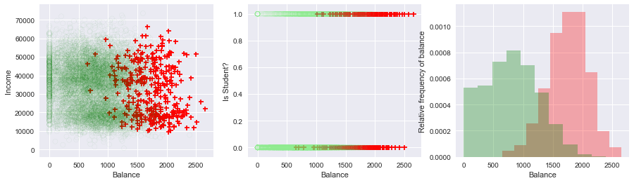

```python
fig, axes = plt.subplots(figsize=(15,4),nrows=1, ncols=3,sharey='col')
axes[0].scatter(defaulters.balance, defaulters.income,c='r',alpha=1,marker='+')
axes[0].scatter(nondefaulters.balance, nondefaulters.income,edgecolors='green', facecolors='none',alpha=.1,marker='o')
axes[0].set_xlabel('Balance')
axes[0].set_ylabel('Income')
axes[1].scatter(defaulters.balance,defaulters.student01,color='r',alpha=1,marker='+')
axes[1].scatter(nondefaulters.balance,nondefaulters.student01,edgecolors='lightgreen', facecolors='none',alpha=.05,marker='o')
axes[1].set_xlabel('Balance')
axes[1].set_ylabel('Is Student?')
axes[2].hist(defaulters.balance,color='r',alpha=0.3,normed=True)
axes[2].hist(nondefaulters.balance,color='g',alpha=0.3,normed=True)
axes[2].set_xlabel('Balance')
axes[2].set_ylabel('Relative frequency of balance')
```

It appears from the scatter plot that "balance" is a reasonable predictor of credit card default. Let us look at the the values that the balance variable can take, and plot a histogram for each of the two classes -- defaulters (in red) and non-defaulters (in green).

```python
binedge=np.linspace(0,2700-5,50)
mid=np.mean((binedge[1:]-binedge[:-1])/2)
binmid=binedge[:-1]+mid
defhist=np.histogram(defaulters.balance,bins=binedge)
nondefhist=np.histogram(nondefaulters.balance,bins=binedge)

def logodds(a, b):
    # take log ( ratio of probabilities of (x vs not-x) )
    eps=1e-10
    a=a+eps
    b=b+eps
#    return np.log(a/(a+b)) This was a mistake
    return np.log(a/b)
```

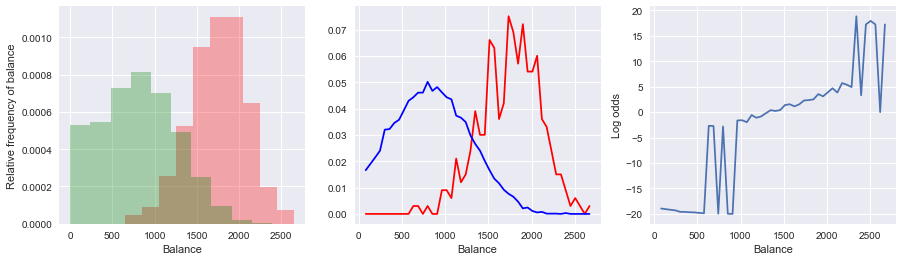

```python
# drop the bin corresponding to 0 balance
defhist1=defhist[0][1:]
nondefhist1=nondefhist[0][1:]
fig, axes = plt.subplots(figsize=(15,4),nrows=1, ncols=3)
axes[0].hist(defaulters.balance,color='r',alpha=0.3,normed=True)
axes[0].hist(nondefaulters.balance,color='g',alpha=0.3,normed=True)
axes[0].set_xlabel('Balance')
axes[0].set_ylabel('Relative frequency of balance')
# drop the bin corresponding to 0 balance in the next line (that's what [1:] is for)
axes[1].plot(binmid[1:],defhist1/defhist1.sum(),c='r')
axes[1].plot(binmid[1:],nondefhist1/nondefhist1.sum(),c='b')
axes[1].set_xlabel('Balance')
axes[2].plot(binmid[1:],logodds(defhist1/defhist1.sum(),nondefhist1/nondefhist1.sum()))
axes[2].set_xlabel('Balance')
axes[2].set_ylabel('Log odds')
```

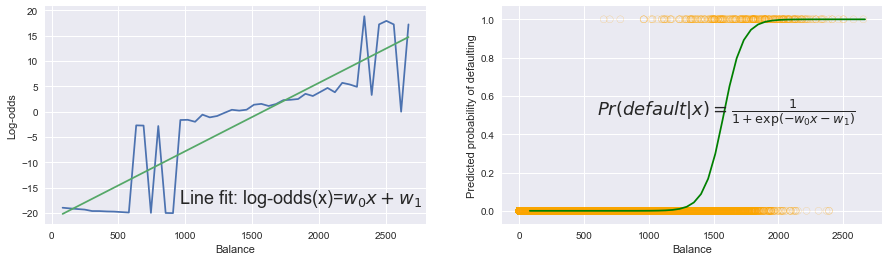

```python
fig, axes = plt.subplots(figsize=(15,4),nrows=1, ncols=2)
y2=logodds(defhist1/defhist1.sum(),nondefhist1/nondefhist1.sum())
lrfit=np.polyfit(binmid[1:],y2,deg=1)
axes[0].plot(binmid[1:],y2)
axes[0].plot(binmid[1:],(lrfit[0]*binmid[1:]+lrfit[1]))
axes[0].set_xlabel('Balance')
axes[0].set_ylabel('Log-odds')
axes[0].text(950,-18, r'Line fit: log-odds(x)=$w_0x+w_1$', fontsize=18)
axes[1].scatter(df.balance,df.default01,facecolors='none',edgecolors='orange',alpha=0.5,marker='o')
axes[1].plot(binmid[1:],1/(1+np.exp(-(lrfit[0]*binmid[1:]+lrfit[1]))),c='g')
axes[1].set_xlabel('Balance')
axes[1].set_ylabel('Predicted probability of defaulting')
axes[1].text(600,0.5, r'$Pr({default}|x)=\frac{1}{1+\exp(-w_0x-w_1)}$', fontsize=18)
```

# The close relationship between the use of probability/statistics and linear algebra in machine learning

In the first example (regression) we used linear algebra and made a connection with ideas from statistics. For the best fit parameters given the choice of model (the output being a linear function of the input) the mean of the residuals was zero and the data was uncorrelated with the residuals. In the second example, the classification task which produced a probability of a category (defaulting on credit cards) based on some informative input (balance on the card) used a straight line fit. This regression would be performed using the linear algebra procedure of taking the Moore-Penrose pseudo-inverse as above.